# poblacion historica

Federico Tricarico

2025-04-24

## Import data

Con datos del Min de interior…

```r
datapob <- readxl::read_excel("~/GitHub/mortalidad_historica/data/poblacion-provincia-argentina-1914-2022.xlsx",
                              sheet = "Hoja1",
                              range = "A1:K25")
datapob
```

```
## # A tibble: 24 × 11
##    Region   Provincia   `1914`  `1947` `1960` `1970` `1980` `1991` `2001` `2010`
##    <chr>    <chr>        <dbl>   <dbl>  <dbl>  <dbl>  <dbl>  <dbl>  <dbl>  <dbl>
##  1 PAMPEANA CABA       1575814 2981043 2.97e6 2.97e6 2.92e6 2.97e6 2.78e6 2.89e6
##  2 PAMPEANA BSAS       2066948 4273874 6.77e6 8.77e6 9.77e6 1.26e7 1.38e7 1.56e7
##  3 PAMPEANA Cordoba     735472 1497987 1.75e6 2.06e6 2.41e6 2.77e6 3.07e6 3.31e6
##  4 PAMPEANA SantaFe     899640 1702975 1.88e6 2.14e6 2.47e6 2.80e6 3.00e6 3.19e6
##  5 PAMPEANA Entre Rios  425373  787362 8.05e5 8.12e5 9.08e5 1.02e6 1.16e6 1.24e6
##  6 PAMPEANA LaPampa     101338  169480 1.59e5 1.72e5 2.08e5 2.60e5 2.99e5 3.19e5
##  7 NORDESTE Chaco        46274  430555 5.43e5 5.67e5 7.01e5 8.40e5 9.84e5 1.06e6
##  8 NORDESTE Misiones     53563  246396 3.61e5 4.43e5 5.89e5 7.89e5 9.66e5 1.10e6
##  9 NORDESTE Corrientes  347055  525463 5.33e5 5.64e5 6.61e5 7.96e5 9.31e5 9.93e5
## 10 NORDESTE Formosa      19281  113790 1.79e5 2.34e5 2.96e5 3.98e5 4.87e5 5.30e5
## # ℹ 14 more rows
## # ℹ 1 more variable: `2022` <dbl>
```

Ahora debemos transformar esta tabla.

```r
poblacion_censos <- pivot_longer(datapob,
                                 cols = 3:11,
                                 names_to = "ronda_censal",
                                 values_to = "poblacion")

poblacion_censos
```

```
## # A tibble: 216 × 4
##    Region   Provincia ronda_censal poblacion
##    <chr>    <chr>     <chr>            <dbl>
##  1 PAMPEANA CABA      1914           1575814
##  2 PAMPEANA CABA      1947           2981043
##  3 PAMPEANA CABA      1960           2966634
##  4 PAMPEANA CABA      1970           2972453
##  5 PAMPEANA CABA      1980           2922829
##  6 PAMPEANA CABA      1991           2965403
##  7 PAMPEANA CABA      2001           2776138
##  8 PAMPEANA CABA      2010           2890151
##  9 PAMPEANA CABA      2022           3121707
## 10 PAMPEANA BSAS      1914           2066948
## # ℹ 206 more rows
```

Los años estan como character, y deberian ser integer Veamos si tenemos el total

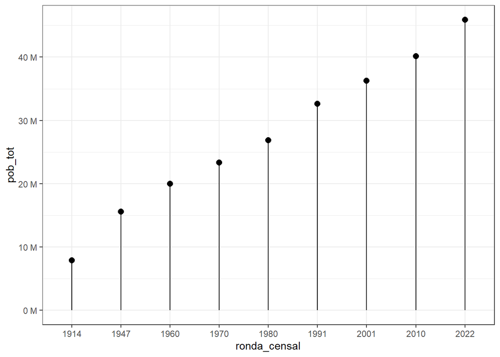

```r
#requiere scales() package
grafico4 <- poblacion_censos |>
  group_by(ronda_censal) |>
  summarise(
    pob_tot = sum(poblacion)
  ) |>
  ggplot(aes(x=ronda_censal, y=pob_tot))+
  geom_point(size = 2.5)+
  geom_segment(aes(x=ronda_censal, xend = ronda_censal, y=pob_tot, yend = 0))+
  scale_y_continuous(labels = unit_format(unit = "M", scale = 1e-6))+
  theme_bw()
grafico4
```

Para ver la provincias podemos usar un geofacet

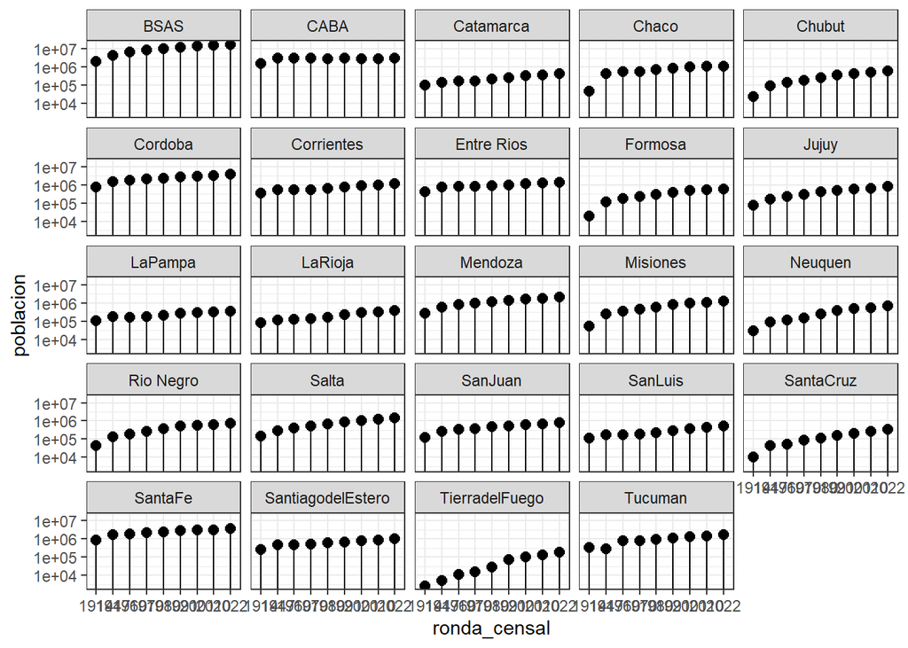

```r
#requiere scales() package
grafico4_1 <- poblacion_censos |>
  ggplot(aes(x=ronda_censal, y=poblacion))+
  geom_point(size = 2.5)+
  geom_segment(aes(x=ronda_censal, xend = ronda_censal, y=poblacion, yend = 0))+
  facet_wrap(~Provincia)+
  scale_y_log10()+
  #scale_y_continuous(labels = unit_format(unit = "M", scale = 1e-6))+
  theme_bw()
grafico4_1
```

Nos interesan particularmente los casos de :

- Territorios Nacionales (Chaco y Patagonia)
- Variaciones intercensales Negativas (Tucuman)
- Las diferencias en el orden magnitud, posibilidad de regionalizar

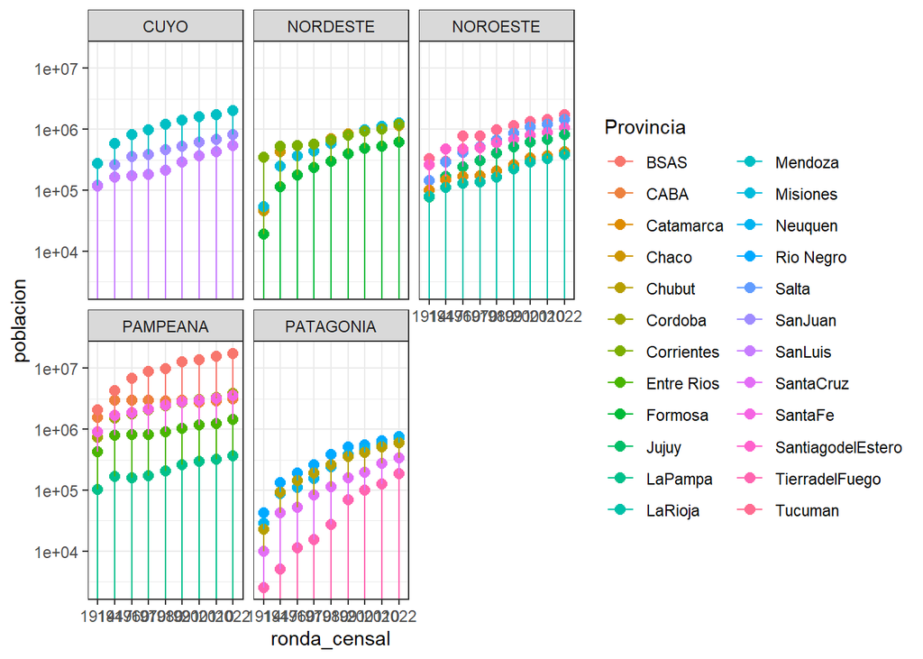

```r
grafico4_2 <- poblacion_censos |>
  ggplot(aes(x=ronda_censal, y=poblacion, color=Provincia))+
  geom_point(size = 2.5)+
  geom_segment(aes(x=ronda_censal, xend = ronda_censal, y=poblacion, yend = 0))+
  facet_wrap(~Region)+
  scale_y_log10()+
  #scale_y_continuous(labels = unit_format(unit = "M", scale = 1e-6))+
  scale_x_discrete(position = "bottom")+
  theme_bw()
grafico4_2
```

Para ver un grafico por regiones apiladas por hacer geom_area, y ver apilado

```r
poblacion_censos$ronda_censal <- as.integer(poblacion_censos$ronda_censal)
```

```r
# grafico5 <- poblacion_censos |>
#   ggplot(aes(x=ronda_censal, y=poblacion, group = Region, fill = Region))+
#   geom_bar(position="stack", stat="identity")+
#   scale_fill_viridis(discrete = T)+
#   scale_y_continuous(labels = unit_format(unit = "M", scale = 1e-6))+
#   theme_ipsum()
#
#
# grafico5
  #geom_bar position, dodge, stack or fill
```

Ahora, como estimar una poblacion para cada año? Se requiere una `funcion` de interpolacion lineal o spline para cada provincia. y una serie con los años de destino de 1914-2022

```r
serie_tiempo <- seq(1914, 2022, by=1)
```

creamos una funcion

```r
interpol <- function(data) {
  #Lineal
  interp_lineal <- approx(data$ronda_censal, data$poblacion, xout = serie_tiempo)$y
  #Spline
  interp_spline <- spline(data$ronda_censal, data$poblacion, xout = serie_tiempo)$y

  #creacion de dataframe

  pop_intepol <- data.frame(
    Year = serie_tiempo,
    estimada_lineal = interp_lineal,
    estimada_spline = interp_spline
  )

  return(pop_intepol)
}
```

Ahora aplicamos esta funcion al dataframe de origen de los datos.

```r
poblacion_interp <- poblacion_censos |>
  group_by(Provincia) |>
  group_modify(~interpol(.x))
```

Veamos el resultado

```r
poblacion_interp
```

```
## # A tibble: 2,616 × 4
## # Groups:   Provincia [24]
##    Provincia  Year estimada_lineal estimada_spline
##    <chr>     <dbl>           <dbl>           <dbl>
##  1 BSAS       1914        2066948         2066948
##  2 BSAS       1915        2133825.        1996454.
##  3 BSAS       1916        2200701.        1937111.
##  4 BSAS       1917        2267578.        1888670.
##  5 BSAS       1918        2334454.        1850883.
##  6 BSAS       1919        2401331.        1823503.
##  7 BSAS       1920        2468207.        1806280.
##  8 BSAS       1921        2535084.        1798966.
##  9 BSAS       1922        2601960.        1801314.
## 10 BSAS       1923        2668837.        1813075.
## # ℹ 2,606 more rows
```

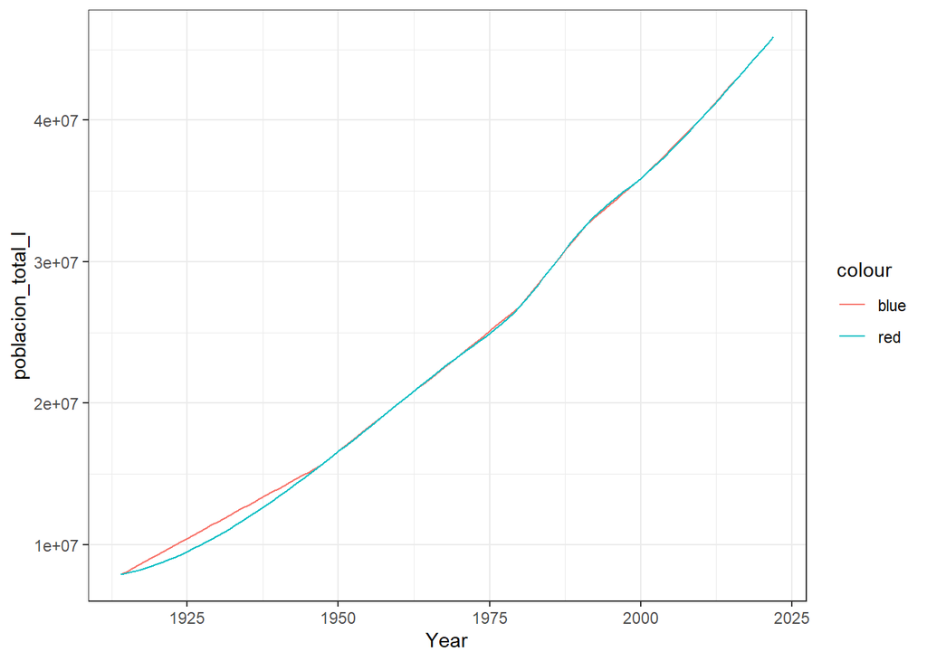

```r
grafico5 <- poblacion_interp |>
  group_by(Year) |>
  summarise(
    poblacion_total_l = sum(estimada_lineal),
    poblacion_total_sp = sum(estimada_spline)
  ) |>
  ggplot()+
  geom_line(aes(x=Year, y=poblacion_total_l, colour = "blue"))+
  geom_line(aes(x=Year, y=poblacion_total_sp, colour = "red"))+
  theme_bw()
grafico5
```

Como se observa en el grafico, spline es mas sensible, que se denota por la pendiente al inicio de la serie.

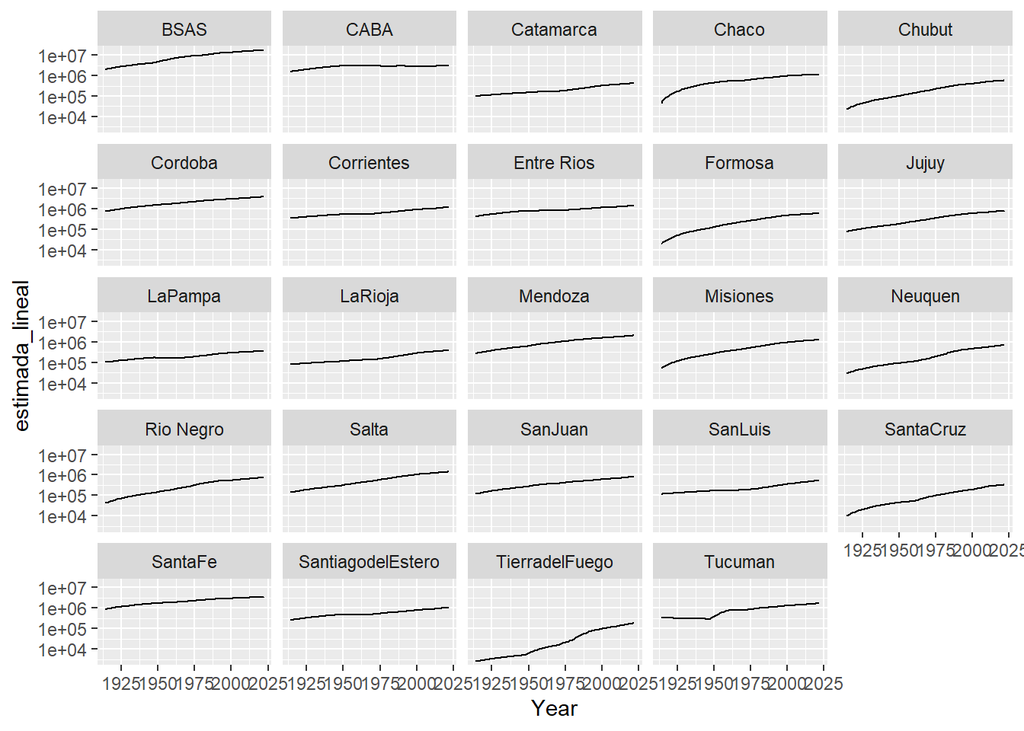

```r
grafico6 <- poblacion_interp |>
  ggplot()+
  geom_line(aes(x=Year, y=estimada_lineal))+
  scale_y_log10()+
  facet_wrap(~Provincia)
grafico6
```

- Revisar el caso de Tucuman y de CABA entre 1914-1947

## Notas

Funciona bien el ajuste lineal aunque no sea el mejor.  
Para ajustar por edad y sexo, se puede usar `interp` del paquete DemoTools que aplica el metodo de AGEINT de PAS.

### Pendientes

- Unir dataset de poblacion estimada (interpolacion lineal) al dataset de defunciones
- Estimar la Tasa Bruta de Mortalidad
- Seleccionar indicadores para hacer comparaciones y analizar la evolucion:
  - Variabilidad o Convergencia?
  - Mapas
  - Series Temporales
  - Serie Espacio Temporal
  - Enumerar episodios de enfermedad relevantes (epidemias)
  - Meta analisis de censos historicos por provincia

#### Proyecto siguiente

- Construir dataset de poblacion por edad y sexo con residencia habitual por provincia, para los censos, y usar interp para interpolar la poblacion, Luego solicitar datos de defunciones por provincia por edad y sexo,